# EST-46114 Métodos Multivariados y Datos Categóricos Trabajo Final

## 3.2 Pregunta 2

**2. Evaluar si la casa encuestadora es independiente de los resultados de la intención de voto.**

Las cuatro variables de interés para esta pregunta son: partido con mayor intención de voto, casa encuestadora , elección (año) y tiempo antes de la elección.

- Partido con mayor intención de voto

```
## [1] "1" "2" "3"
```

- Casa encuestadora

```
##  [1] "1"  "2"  "3"  "4"  "5"  "6"  "7"  "8"  "9"  "10" "11" "12" "13" "14"
## [15] "15" "16" "17" "18" "19" "20" "21" "22" "23" "24" "25" "26" "27" "28"
## [29] "29" "30" "31" "32" "33" "34" "35" "36" "37" "38" "39" "40"
```

- Elección

```
## [1] "1" "2" "3" "4"
```

*Tiempo antes de la elección

```
##  [1] "5"  "10" "15" "20" "25" "30" "35" "40" "45" "50"
```

Construimos la tabla de contingencia para las cuatro variables de interes, que tiene un soporte de $\chi = 3\times40\times4\times10$.

La tabla de contingencia está organizada en cuatro dimensiones dada su extensión no se muestra en el documento ejecutivo.

Recuperamos la tabla de contingencias en formato de DataFrame para poder utilizar en el algoritmo y en la prueba de hipótesis:

```
##   partido_favorito pollster_id year_id tiempo_antes_de_la_eleccion freq
## 1                1           1       1                           1    1
## 2                1           1       1                           2    4
## 3                1           1       1                           3    2
## 4                1           1       1                           4    1
## 5                1           1       1                           6    8
## 6                1           1       1                           7    1
```

Cada entrada del DataFrame es una configuración del soporte.

### 3.2.1 Descripción del Procedimiento de Estimación con Justificación

Se prueban diferentes especificaciones utilizando el algoritmo MC3.

Abajo se muestran los seis mejores modelos.

```
##                                                                                             formula
## 1                   [partido_favorito,pollster_id][pollster_id,year_id,tiempo_antes_de_la_eleccion]
## 2                               [partido_favorito][pollster_id,year_id,tiempo_antes_de_la_eleccion]
## 3                  [partido_favorito,pollster_id][pollster_id,tiempo_antes_de_la_eleccion][year_id]
## 4                              [partido_favorito][pollster_id,tiempo_antes_de_la_eleccion][year_id]
## 5                       [partido_favorito,year_id][pollster_id,year_id,tiempo_antes_de_la_eleccion]
## 6 [partido_favorito,pollster_id][partido_favorito,year_id][pollster_id,tiempo_antes_de_la_eleccion]
##   logPostProb
## 1    2287.013
## 2    2286.863
## 3    2286.835
## 4    2286.464
## 5    2284.932
## 6    2284.834
```

Se puede observar que el modelo con mayor log-posteior probabilidad es un modelo donde el partido favorito es condicionalmente independiente de año y tiempo dado la casa encuestadora. Ya que lo que nos interesa es probar si existen dependencias condicionales, nos quedamos ese modelo, el cuál se ve de la siguiente manera:

$$X_{\text{intención de voto}} \bigCI(X_\text{año de elecció}, X_\text{tiempo antes de elección})|X_\text{casa encuestadora}$$

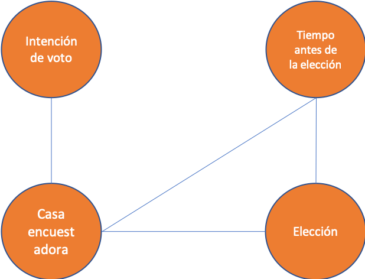

### 3.2.2 Prueba de Hipótesis

Ahora, se realizan un conjunto de pruebas de hipótesis para verificar estos resultados de manera estadística.

```
## Testing partido_favorito _|_ year_id | pollster_id
## Statistic (DEV):  175.778 df: 90 p-value: 0.0000 method: CHISQ
## Slice information:
##    statistic  p.value df pollster_id
## 1    13.8574 0.031270  6           1
## 2     0.0000 1.000000  0           2
## 3    13.7425 0.032648  6           3
## 4     0.1244 0.724357  1           4
## 5     0.6085 0.737677  2           5
## 6     0.0000 1.000000  0           6
## 7     0.0000 1.000000  0           7
## 8     0.0000 1.000000  0           8
## 9     0.2537 0.880870  2           9
## 10    7.7241 0.005449  1          10
## 11    2.5722 0.276343  2          11
```

[output cut: 29 more lines]

Para poder sacar conclusiones, se calculan los estadísticos con un nivel del 95% de confianza, con el objetivo de realizar la prueba de hipótesis de forma agregada e individual.

- Agregado: Se rechaza la hipótesis nula

```r
qchisq(.95, df=90)
```

```
## [1] 113.1453
```

- Desagregado (ordenados por casos dependiendo de sus grados de libertad)

Caso 4 (CNN): *No se rechaza la hipótesis nula*

Caso 10 (GroveInsight): Se rechaza la hipótesis nula

Caso 19 (MonmouthUniversity): *No se rechaza la hipótesis nula*

```r
qchisq(.95, df=1)
```

```
## [1] 3.841459
```

Caso 5 (CNN/Time): *No se rechaza la hipótesis nula*

Caso 9 (GravisMarketing): *No se rechaza la hipótesis nula*

Caso 11 (InsiderAdvantage): *No se rechaza la hipótesis nula*

Caso 12 (Ipsos): *No se rechaza la hipótesis nula*

Cso 27 (Research200): *No se rechaza la hipótesis nula*

Caso 30 (StrategicVision): Se rechaza la hipótesis nula

Caso 39 (youGov): *No se rechaza la hipótesis nula*

```r
qchisq(.95, df=2)
```

```
## [1] 5.991465
```

Caso 28 (Serze&Co): *No se rechaza la hipótesis nula*

```r
qchisq(.95, df=3)
```

```
## [1] 7.814728
```

Caso 16 (MaristCollege): Se rechaza la hipótesis nula

Caso 22 (PublicPolicyPolling): *No se rechaza la hipótesis nula*

Caso 29 (SienaResearchInstitute): *No se rechaza la hipótesis nula*

Caso 34 (UniversityofCincinnati): *No se rechaza la hipótesis nula*

```r
qchisq(.95, df=4)
```

```
## [1] 9.487729
```

Caso 1 (0_None): Se rechaza la hipótesis nula

Caso 3 (ARG): Se rechaza la hipótesis nula

Caso 14 (LATimes): *No se rechaza la hipótesis nula*

Caso 17 (MasonDixon): *No se rechaza la hipótesis nula*

Caso 24 (Quinnipiac): Se rechaza la hipótesis nula

Caso 25 (Rasmussen): Se rechaza la hipótesis nula

Caso 31 (SuffolkUniversity): *No se rechaza la hipótesis nula*

Caso 33 (SurveyUSA): Se rechaza la hipótesis nula

Caso 35 (UniversityofNewHampshire): *No se rechaza la hipótesis nula*

```r
qchisq(.95, df=6)
```

```
## [1] 12.59159
```

Cuando los grados de libertad son iguales a 0 el estadístico es igual a 0, por lo tanto, *No se rechaza la hipótesis nula*.

# 4. Comentarios Finales

Para finalizar el proyecto hay dos puntos que vale la pena recalcar, en primero y en un contexto de contenido del curso, el análisis y construccion de modelos con grafos, es una herramienta muy útil que permite visualizar diferentes escenarios de una situación, visualización que permite indagar con más profundidad en el problema en cuestión. Por ejemplo, de manera agregada aquí se mostró que puede haber independencia condicional, pero de manera desagregada no. Como en el caso de casas encuestadoras.

En segundo lugar, y en el contexto de las elecciones de Estados Unidos, el tener esta información disponible permite analizar el comportamiento a lo largo de los tiempos en relación con las casas encuestadoras y su papel en cada estado. Además, y lo más importante a recalcar como conclusión, es sumamente relevante el número de personas que no reportan sus preferencias o que simplemente no saben bien por quién votar, indicando que conforme pasan los años la participación ciudada y su criterio de votación se ve afectado.

# 5. Bibliografía

Bon, J. Ballard, T. and Baffour, B. (2018). Polling bias and undecided voter allocations: US Presidential elections, 2004 - 2016. Journal of the Royal Statistical Society, 1-27.